```r
library(ggplot2)
library(dplyr)
library(car)
library(caret)
library(moments)
library(tseries)
LIGHT_PINK = "#D6B8B7"
DARK_PINK  = "#C39897"
LIGHT_PURPLE = "#B5B2BA"
DARK_PURPLE  = "#9B97A2"
```

In this project we will use the data from the source: https://www.kaggle.com/rikdifos/credit-card-approval-prediction. There are two data frames, containing the aspects of bank clients’ life and data about taking a loan and the overdue of its payoff.

credit_record.csv contains the client’s ID and the loan status, depicting no loan at all, or the number of days overdue.

```r
credits <- read.csv("credit_record.csv")
head(credits)
```

```
##        ID MONTHS_BALANCE STATUS
## 1 5001711              0      X
## 2 5001711             -1      0
## 3 5001711             -2      0
## 4 5001711             -3      0
## 5 5001712              0      C
## 6 5001712             -1      C
```

application_record.csv describes the factors of the client. We will rid off the unimportant factors, and also reject the mismatched one.

```r
apps <- read.csv("application_record.csv")
head(apps)
```

```
##        ID CODE_GENDER FLAG_OWN_CAR FLAG_OWN_REALTY CNT_CHILDREN
## 1 5008804           M            Y               Y            0
## 2 5008805           M            Y               Y            0
## 3 5008806           M            Y               Y            0
## 4 5008808           F            N               Y            0
## 5 5008809           F            N               Y            0
## 6 5008810           F            N               Y            0
##   AMT_INCOME_TOTAL     NAME_INCOME_TYPE           NAME_EDUCATION_TYPE
## 1           427500              Working              Higher education
## 2           427500              Working              Higher education
## 3           112500              Working Secondary / secondary special
## 4           270000 Commercial associate Secondary / secondary special
## 5           270000 Commercial associate Secondary / secondary special
## 6           270000 Commercial associate Secondary / secondary special
##     NAME_FAMILY_STATUS NAME_HOUSING_TYPE DAYS_BIRTH DAYS_EMPLOYED FLAG_MOBIL
## 1       Civil marriage  Rented apartment     -12005         -4542          1
## 2       Civil marriage  Rented apartment     -12005         -4542          1
## 3              Married House / apartment     -21474         -1134          1
## 4 Single / not married House / apartment     -19110         -3051          1
## 5 Single / not married House / apartment     -19110         -3051          1
## 6 Single / not married House / apartment     -19110         -3051          1
##   FLAG_WORK_PHONE FLAG_PHONE FLAG_EMAIL OCCUPATION_TYPE CNT_FAM_MEMBERS
## 1               1          0          0                               2
## 2               1          0          0                               2
## 3               0          0          0  Security staff               2
## 4               0          1          1     Sales staff               1
## 5               0          1          1     Sales staff               1
## 6               0          1          1     Sales staff               1
```

Also, for convenient plotting, we will replace the string values with the numeric ones.

```r
parse_statuses <- function(value) {
  if (value == "C") {             # loan is paid off in time
    return (-1)
  }
  else if (value == "X") {        # no loan for the month
    return (-2)
  }
  else {
    return (as.numeric(value))    # number of month of the loan payoff delay
  }
}
```

```r
parse_gender <- function(value) {
  if (value == "F") {             # female
    return (0)
  } else {                        # male
    return (1)
  }
}
```

```r
parse_education <- function(value) {
  if (value == "Secondary / secondary special") {
    return (0)
  }
  else if (value == "Higher education") {
    return (1)
  }
  else {
    return (-1)
  }
}
```

```r
parse_education_2 <- function(value) {
  if (value == "Secondary / secondary special") {
    return (1)
  }
  else if (value == "Higher education") {
    return (2)
  }
  else {
    return (0)
  }
}
```

```r
parse_age <- function(value) {
  age <- as.numeric(value)
  return(-age%/%365)
}
```

```r
parse_working_years <- function(value) {
  if (value < 0) {
    years <- as.numeric(value)
    return(-years%/%365)
  }
  else {
    return(0)
  }
}
```

```r
parse_family_status <- function(value) {
  if (value == "Married") {
    return (0)
  }
  else if (value == "Single / not married") {
    return (1)
  }
  else {
    return (-1)
  }
}
```

```r
parse_family_status_2 <- function(value) {
  if (value == "Married") {
    return (2)
  }
  else if (value == "Single / not married") {
    return (1)
  }
  else {
    return (0)
  }
}
```

```r
merged <- merge(credits, apps, by = "ID")     # merge two df's by the column ID
data   <- dplyr::select(merged, CNT_CHILDREN, AMT_INCOME_TOTAL, CNT_FAM_MEMBERS) # create new df with the selected required columns
# Parse string data into numeric and save into new data frame:
data$NUMERIC_LOANS  <- sapply(merged$STATUS, FUN=parse_statuses)
data$NUMERIC_GENDER <- sapply(merged$CODE_GENDER, FUN=parse_gender)
data$NUMERIC_EDU    <- sapply(merged$NAME_EDUCATION_TYPE, FUN=parse_education)
data$NUMERIC_FAMILY <- sapply(merged$NAME_FAMILY_STATUS, FUN=parse_family_status)
# Filter oservations by boolean value representing taking loan or not
data$has_loan <- data$NUMERIC_LOANS != -2
head(data)
```

```
##   CNT_CHILDREN AMT_INCOME_TOTAL CNT_FAM_MEMBERS NUMERIC_LOANS NUMERIC_GENDER
## 1            0           427500               2            -1              1
## 2            0           427500               2            -1              1
## 3            0           427500               2            -1              1
## 4            0           427500               2            -1              1
## 5            0           427500               2            -1              1
## 6            0           427500               2            -1              1
##   NUMERIC_EDU NUMERIC_FAMILY has_loan
## 1           1             -1     TRUE
## 2           1             -1     TRUE
## 3           1             -1     TRUE
## 4           1             -1     TRUE
## 5           1             -1     TRUE
## 6           1             -1     TRUE
```

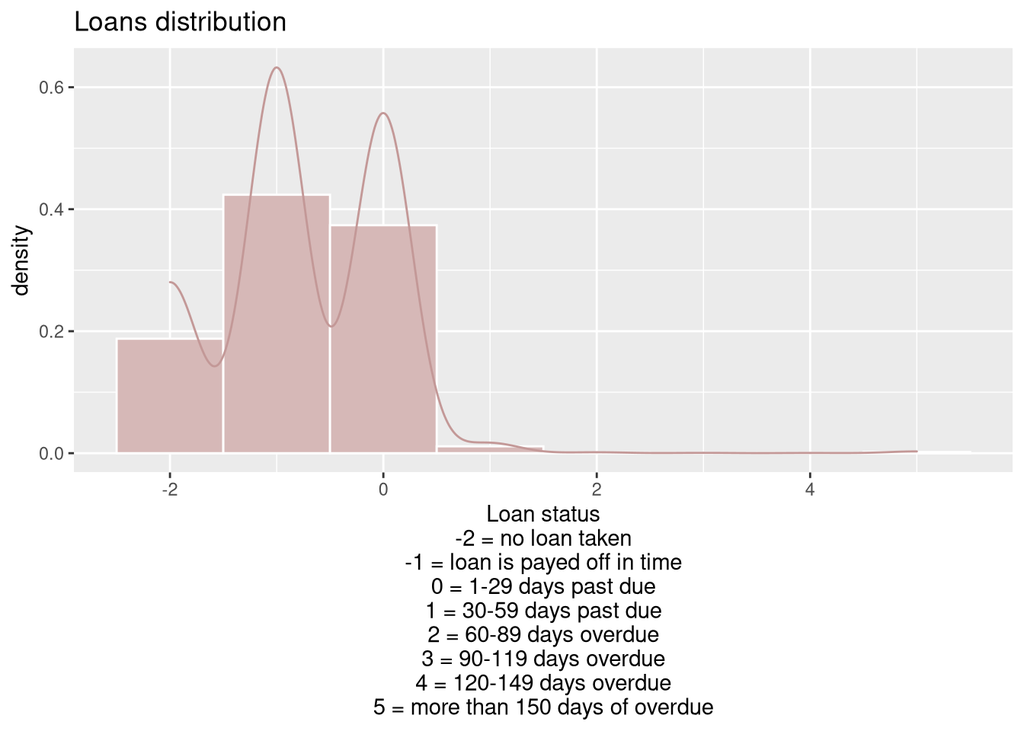

```r
# -2 = no loan taken
# -1 = loan is payed off in time
#  0 = 1-29 days past due
#  1 = 30-59 days past due
#  2 = 60-89 days overdue
#  3 = 90-119 days overdue
#  4 = 120-149 days overdue
#  5 = more than 150 days of overdue
ggplot(data = data, aes(x = NUMERIC_LOANS)) +
  geom_histogram(aes(y = ..density..), binwidth = 1, fill = LIGHT_PINK, color = "white") +
  geom_density(adjust = 6, alpha = 1, col = DARK_PINK) +
  ggtitle("Loans distribution") +
  xlab(label = "Loan status\n-2 = no loan taken\n-1 = loan is payed off in time\n0 = 1-29 days past due\n1 = 30-59 days past due\n2 = 60-89 days overdue\n3 = 90-119 days overdue\n4 = 120-149 days overdue\n5 = more than 150 days of overdue")
```

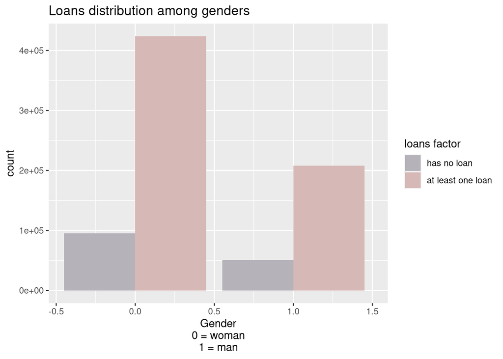

```r
# 0 = woman
# 1 = men
ggplot(data, aes(x = NUMERIC_GENDER, fill = factor(has_loan))) +
  geom_bar(position = "dodge") +
  xlim(NA, 1.5) +
  scale_fill_manual(name = "loans factor", values = c(LIGHT_PURPLE, LIGHT_PINK),
                    labels = c("has no loan", "at least one loan")) +
  ggtitle("Loans distribution among genders") +
  xlab(label = "Gender\n0 = woman\n1 = man")
```

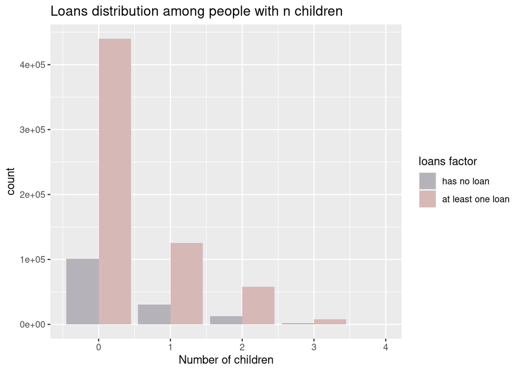

```r
ggplot(data, aes(x = CNT_CHILDREN, fill = factor(has_loan))) +
  geom_bar(position = "dodge") +
  xlim(NA, 4) +
  scale_fill_manual(name = "loans factor", values = c(LIGHT_PURPLE, LIGHT_PINK),
                    labels = c("has no loan", "at least one loan")) +
  ggtitle("Loans distribution among people with n children") +
  xlab(label = "Number of children")
```

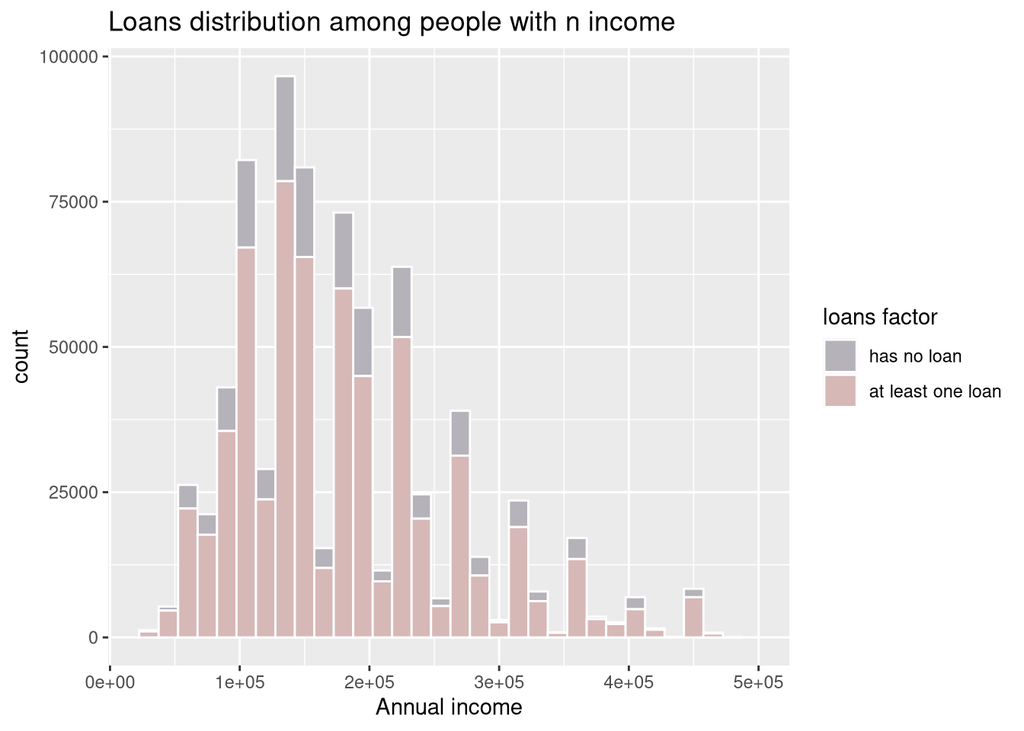

```r
ggplot(data, aes(x = AMT_INCOME_TOTAL, fill = factor(has_loan))) +
  geom_histogram(binwidth = 15000, color = "white") +
  xlim(NA, 500000) +
  scale_fill_manual(name = "loans factor", values = c(LIGHT_PURPLE, LIGHT_PINK),
                    labels = c("has no loan", "at least one loan")) +
  ggtitle("Loans distribution among people with n income") +
  xlab(label = "Annual income")
```

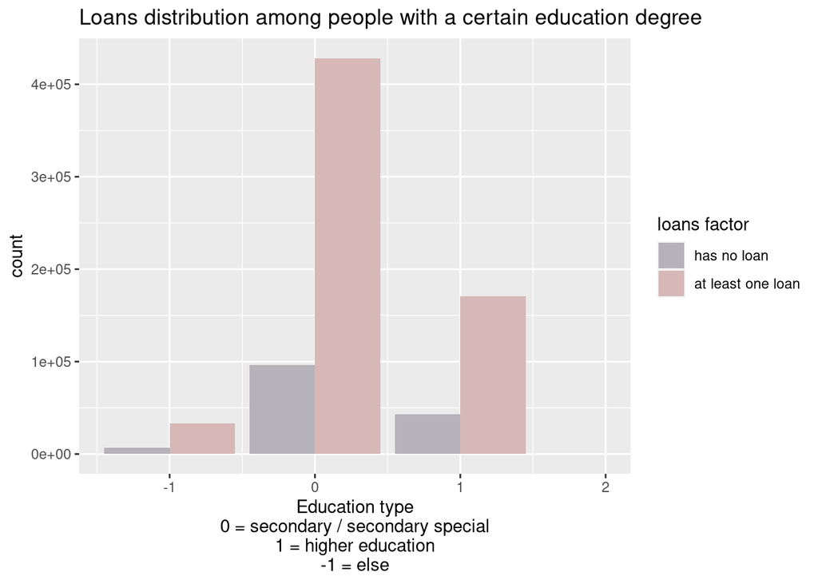

```r
#  0 = secondary / secondary special
#  1 = higher education
# -1 = else
ggplot(data, aes(x = NUMERIC_EDU, fill = factor(has_loan))) +
  geom_bar(position = "dodge") +
  xlim(NA, 2) +
  scale_fill_manual(name = "loans factor", values = c(LIGHT_PURPLE, LIGHT_PINK),
                    labels = c("has no loan", "at least one loan")) +
  ggtitle("Loans distribution among people with a certain education degree") +
  xlab(label = "Education type\n0 = secondary / secondary special\n1 = higher education\n-1 = else")
```

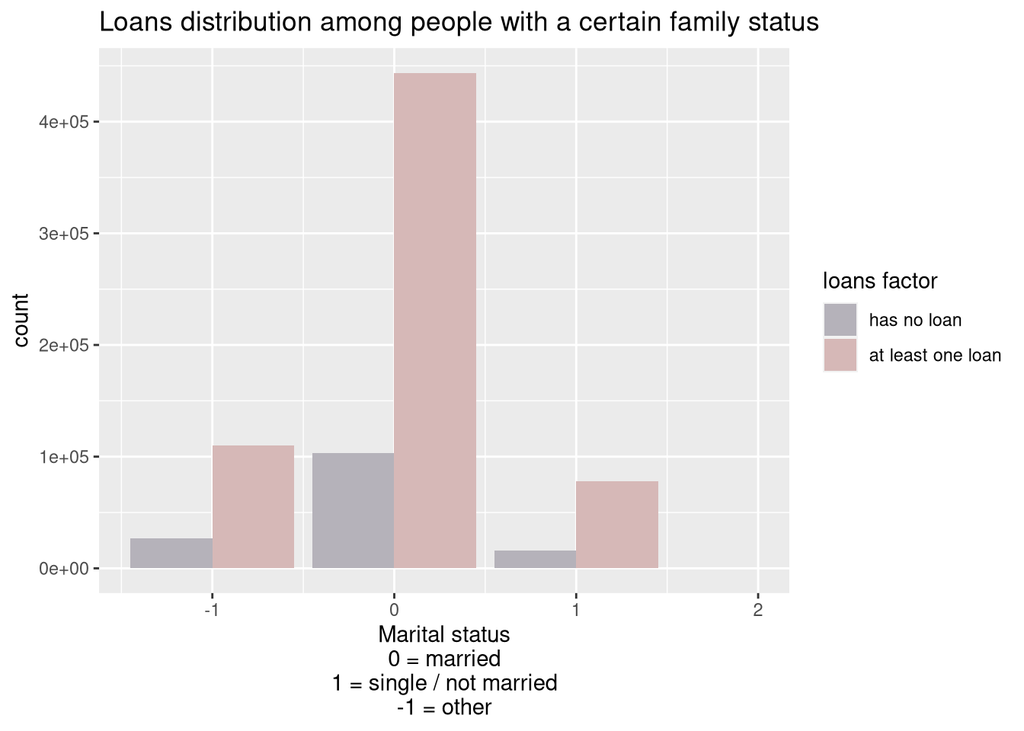

```r
#  0 = married
#  1 = single / not married
# -1 = other
ggplot(data, aes(x = NUMERIC_FAMILY, fill = factor(has_loan))) +
  geom_bar(position = "dodge") +
  xlim(NA, 2) +
  scale_fill_manual(name = "loans factor", values = c(LIGHT_PURPLE, LIGHT_PINK),
                    labels = c("has no loan", "at least one loan")) +
  ggtitle("Loans distribution among people with a certain family status") +
  xlab(label = "Marital status\n0 = married\n1 = single / not married\n-1 = other")
```

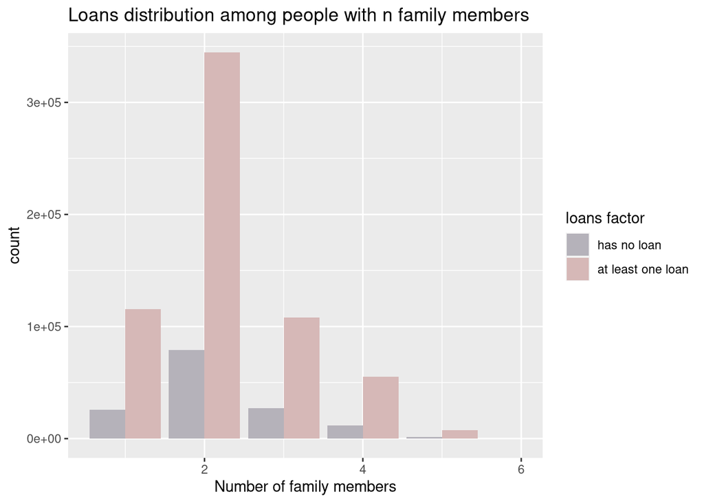

```r
ggplot(data, aes(x = CNT_FAM_MEMBERS, fill = factor(has_loan))) +
  geom_bar(position = "dodge") +
  xlim(NA, 6) +
  scale_fill_manual(name = "loans factor", values = c(LIGHT_PURPLE, LIGHT_PINK),
                    labels = c("has no loan", "at least one loan")) +
  ggtitle("Loans distribution among people with n family members") +
  xlab(label = "Number of family members")
```

##### Hypothesis testing

###### Goal

In this part we will be testing the dependence between loan payoff and different factors of clients. In this way, we will split the clients in two different classes: clients with an overdue and without.

```r
data$overdue <- data$NUMERIC_LOANS >= 0
```

Next we will test each factor using chi-squared test for independence. For each we construct a table consisting of a measure of our factor (represented by rows) and the number of clients with an overdue or without (there are two columns for corresponding categories).

$H_0$ - The client’s gender is independent of delaying a loan payoff  
$H_1$ - There is a dependence between client’s gender and delaying a loan payoff

```r
test_data <- table(data$NUMERIC_GENDER, data$overdue)
test_data
```

```
##
##      FALSE   TRUE
##   0 316734 202117
##   1 158752 100112
```

```r
chisq.test(test_data)
```

```
##
##  Pearson's Chi-squared test with Yates' continuity correction
##
## data:  test_data
## X-squared = 5.7334, df = 1, p-value = 0.01665
```

```r
summary(test_data)
```

```
## Number of cases in table: 777715
## Number of factors: 2
## Test for independence of all factors:
##  Chisq = 5.745, df = 1, p-value = 0.01653
```

$H_0$ - The number of client’s children is independent of delaying a loan payoff  
$H_1$ - There is a dependence between a client having children and delaying a loan payoff

```r
test_data <- table(data$CNT_CHILDREN, data$overdue)[1:6,]
test_data
```

```
##
##      FALSE   TRUE
##   0 331025 209614
##   1  94600  61038
##   2  43147  27252
##   3   5710   3618
##   4    713    511
##   5    245     79
```

```r
chisq.test(test_data)
```

```
##
##  Pearson's Chi-squared test
##
## data:  test_data
## X-squared = 43.726, df = 5, p-value = 2.633e-08
```

$H_0$ - The amount of client’s income is independent of delaying a loan payoff  
$H_1$ - There is a dependence between a client’s income and delaying a loan payoff

```r
test_data <- table(data$AMT_INCOME_TOTAL, data$overdue)
# process data to have higher density
for (row in seq(1, nrow(test_data) - 4, by = 5)) {
  test_data[row,] <- colSums(test_data[row:(row + 4),])
}
test_data <- test_data[seq(1, nrow(test_data), by = 5),]
head(test_data)
```

```
##
##         FALSE TRUE
##   27000   291  215
##   31950   326  188
##   36900   446  181
##   39600  2082 1286
##   45900   923  574
##   50850  1907 1200
```

```r
chisq.test(test_data)
```

```
##
##  Pearson's Chi-squared test
##
## data:  test_data
## X-squared = 1819.7, df = 52, p-value < 2.2e-16
```

$H_0$ - The client’s education is independent of delaying a loan payoff  
$H_1$ - There is a dependence between a client’s education and delaying a loan payoff

```r
test_data <- table(data$NUMERIC_EDU, data$overdue)
test_data
```

```
##
##       FALSE   TRUE
##   -1  24814  15007
##   0  317432 206829
##   1  133240  80393
```

```r
chisq.test(test_data)
```

```
##
##  Pearson's Chi-squared test
##
## data:  test_data
## X-squared = 236.04, df = 2, p-value < 2.2e-16
```

$H_0$ - The client’s marital status is independent of delaying a loan payoff  
$H_1$ - There is a dependence between a client’s marital status and delaying a loan payoff

```r
test_data <- table(data$NUMERIC_FAMILY, data$overdue)
test_data
```

```
##
##       FALSE   TRUE
##   -1  84380  52381
##   0  334065 212554
##   1   57041  37294
```

```r
chisq.test(test_data)
```

```
##
##  Pearson's Chi-squared test
##
## data:  test_data
## X-squared = 36.139, df = 2, p-value = 1.421e-08
```

$H_0$ - The number of client’s family members is independent of delaying a loan payoff  
$H_1$ - There is a dependence between a number of client’s family members and delaying a loan payoff

```r
test_data <- table(data$CNT_FAM_MEMBERS, data$overdue)[1:7,]
test_data
```

```
##
##      FALSE   TRUE
##   1  85874  55603
##   2 260269 163454
##   3  81900  52994
##   4  40843  26147
##   5   5626   3373
##   6    712    484
##   7    216     57
```

```r
chisq.test(test_data)
```

```
##
##  Pearson's Chi-squared test
##
## data:  test_data
## X-squared = 82.792, df = 6, p-value = 9.46e-16
```

##### Summary of tests

In all of the above cases, p-value is less than 0.05, which means that for significance level of 0.05 we reject the null-hypothesis and conclude that there is a dependence between a client delaying a loan and all of those factors. Although for significance level of 0.01 the first test shows that there is no such dependence between a client’s gender and an overdue of a loan.

###### Why this data is important

We can see that it is important for banks to collect those parameters to calculate their clients’ “reliability” factor, thus deciding whether a specific client can take a loan and calculating the amount of money that can be issued.

##### Distributions comparisons

The distributions of the total annual income and the one of the loans seems to be the most interesting ones. We want to compare them with some basic distributions, starting with normal.

But first, lets plot the empirical cumulative distribution functions for each distribution:

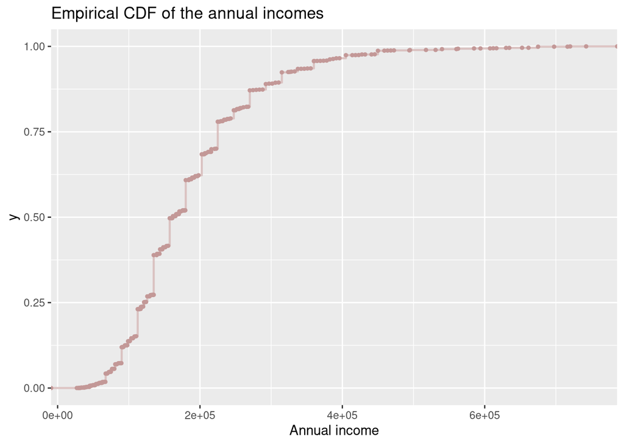

```r
par(mfrow=c(1,2))
ggplot(data, aes(AMT_INCOME_TOTAL)) +
  stat_ecdf(geom = "step", color = LIGHT_PINK, lwd = 0.8, alpha = 0.8) +
  stat_ecdf(geom = "point", color = DARK_PINK, lwd = 1) +
  xlim(NA, 750000) +
  xlab(label = "Annual income") +
  ggtitle("Empirical CDF of the annual incomes")
```

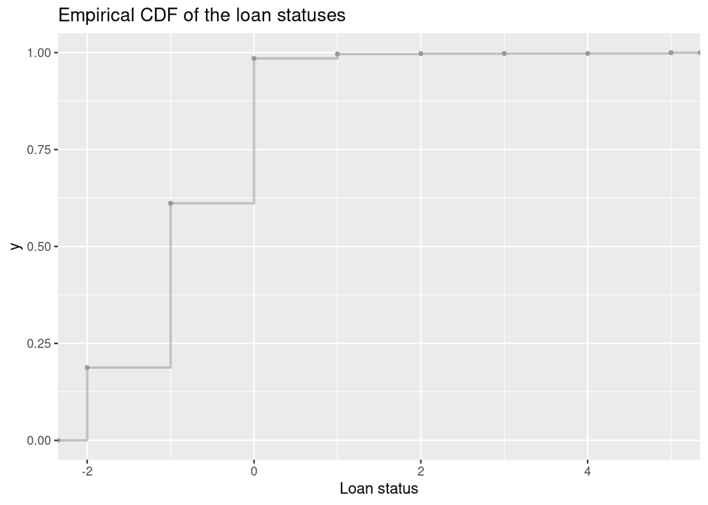

```r
ggplot(data, aes(NUMERIC_LOANS)) +
  stat_ecdf(geom = "step", color = LIGHT_PURPLE, lwd = 0.8, alpha = 0.8) +
  stat_ecdf(geom = "point", color = DARK_PURPLE, lwd = 1) +
  xlab(label = "Loan status") +
  ggtitle("Empirical CDF of the loan statuses")
```

The following are the empirical density of those distributions:

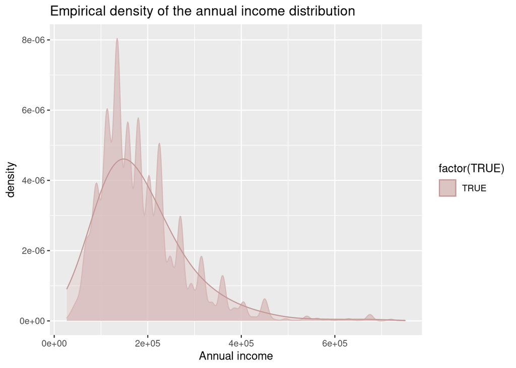

```r
par(mfrow=c(1,2))
ggplot(data, aes(x = AMT_INCOME_TOTAL, fill = factor(TRUE))) +
  xlim(NA, 750000) +
  geom_density(alpha = 0.7, adjust = 1.5, col = LIGHT_PINK) +
  geom_density(alpha = 0.3, adjust = 10,  col = DARK_PINK) +
  scale_fill_manual(values = LIGHT_PINK) +
  xlab(label = "Annual income") +
  ggtitle("Empirical density of the annual income distribution")
```

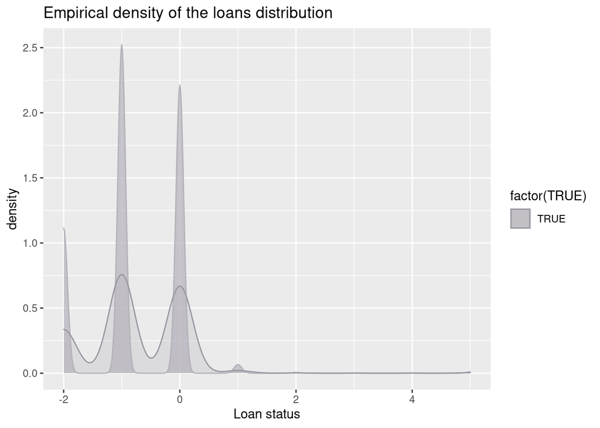

```r
ggplot(data, aes(x = NUMERIC_LOANS, fill = factor(TRUE))) +
  geom_density(alpha = 0.7, adjust = 1.5, col = LIGHT_PURPLE) +
  geom_density(alpha = 0.3, adjust = 5,   col = DARK_PURPLE) +
  scale_fill_manual(values = LIGHT_PURPLE) +
  xlab(label = "Loan status") +
  ggtitle("Empirical density of the loans distribution")
```

From the plots, we can see, that they are both not likely to be normal. For example, the density of the total annual income is obviously right-skewed. Such parameters as skewness and kurtosis coefficient can be useful in determining the distribution, and also for our future steps:

```r
skewness(data$AMT_INCOME_TOTAL)
```

```
## [1] 2.577637
```

```r
kurtosis(data$AMT_INCOME_TOTAL)
```

```
## [1] 18.80448
```

```r
skewness(data$NUMERIC_LOANS)
```

```
## [1] 0.6413909
```

```r
kurtosis(data$NUMERIC_LOANS)
```

```
## [1] 7.459088
```

We want to check whether distributions of annual income and of the loan statuses are normal. To test that, we will use Jarque-Bera test in spite of the Shapiro-Wilk test because of the large sample size.

Jarque-Bera test is a goodness-of-fit test of whether sample data have the skewness and kurtosis matching a normal distribution. We already found the values of skewness and kurtosis for each distribution, and they are non-normal, but still, lets check this with the following test.

Samples from a normal distribution have an expected skewness of 0 and an expected excess kurtosis of 0 (which is the same as a kurtosis of 3), so by that principle we build our hypothesis:

$H_0$: The skewness and the excess kurtosis are both zero = the distribution is normal $H_1$: The skewness and the excess kurtosis are not both zero = the distribution is not normal

```r
jarque.bera.test(data$AMT_INCOME_TOTAL)
```

```
##
##  Jarque Bera Test
##
## data:  data$AMT_INCOME_TOTAL
## X-squared = 8955340, df = 2, p-value < 2.2e-16
```

```r
jarque.bera.test(data$NUMERIC_LOANS)
```

```
##
##  Jarque Bera Test
##
## data:  data$NUMERIC_LOANS
## X-squared = 697642, df = 2, p-value < 2.2e-16
```

As we can see, both tests gave a very small p-value, less than the significance level $\alpha = 0.05$, so we reject the null hypothesis. Thus, distributions of the annual income and the loans are both not normal.

This proves the following Quantile-Quantile plots:

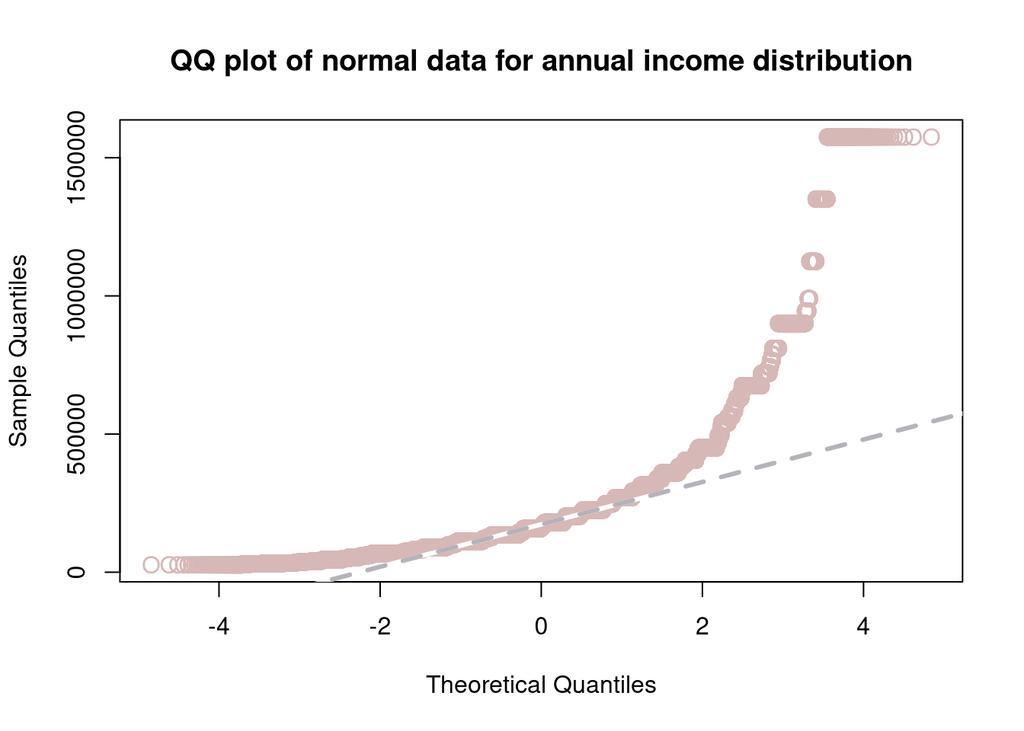

```r
qqnorm(data$AMT_INCOME_TOTAL, main="QQ plot of normal data for annual income distribution", pch="O", col=LIGHT_PINK)
qqline(data$AMT_INCOME_TOTAL, lty=1, lwd=3, col="white")
qqline(data$AMT_INCOME_TOTAL, lty=2, lwd=3, col=LIGHT_PURPLE)
```

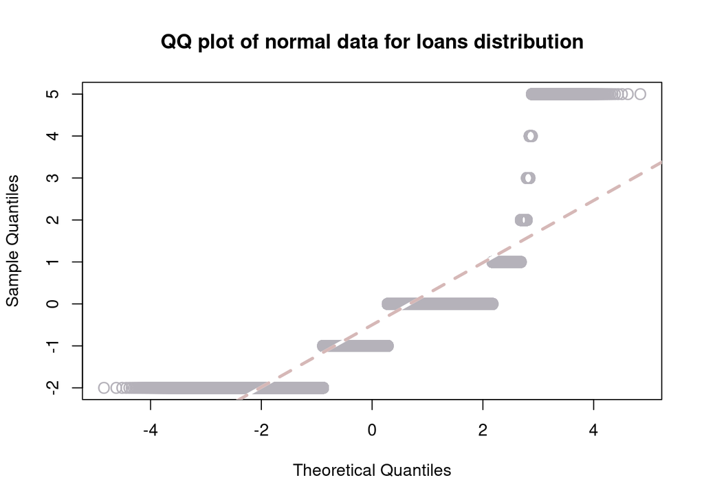

```r
qqnorm(data$NUMERIC_LOANS, main="QQ plot of normal data for loans distribution", pch="O", col=LIGHT_PURPLE)
qqline(data$NUMERIC_LOANS, lty=1, lwd=3, col="white")
qqline(data$NUMERIC_LOANS, lty=2, lwd=3, col=LIGHT_PINK)
```

But also we want to check which others distributions they can follow. For that, lets firstly again visualize the Quantile-Quantile plots:

```r
par(mfrow=c(2,2))
qqPlot(data$AMT_INCOME_TOTAL, "norm",  pch="*", col=LIGHT_PINK, col.lines=DARK_PURPLE)
```

```
## [1] 725434 725435
```

```r
qqPlot(data$AMT_INCOME_TOTAL, "lnorm", pch="*", col=LIGHT_PINK, col.lines=DARK_PURPLE)
```

```
## [1] 725434 725435
```

```r
qqPlot(data$AMT_INCOME_TOTAL, "exp",   pch="*", col=LIGHT_PINK, col.lines=DARK_PURPLE)
```

```
## [1] 725434 725435
```

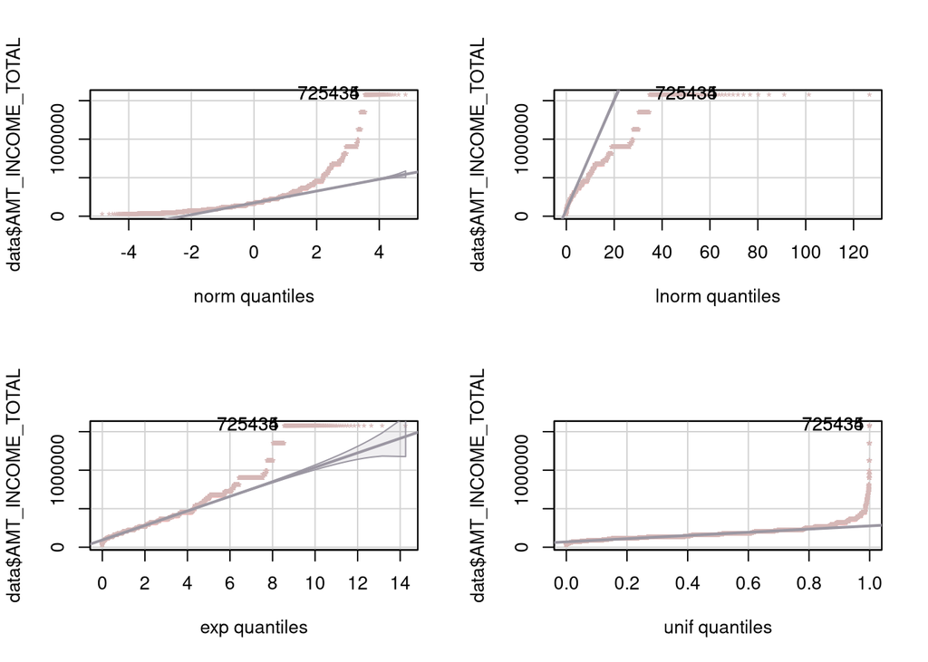

```
## [1] 725434 725435
```

```r
qqPlot(data$AMT_INCOME_TOTAL, "unif",  pch="*", col=LIGHT_PINK, col.lines=DARK_PURPLE)
```

```r
par(mfrow=c(2,2))
qqPlot(data$NUMERIC_LOANS, "norm",  pch="*", col=LIGHT_PURPLE, col.lines=DARK_PINK)
```

```
## [1] 300 311
```

```r
qqPlot(data$NUMERIC_LOANS, "lnorm", pch="*", col=LIGHT_PURPLE, col.lines=DARK_PINK)
```

```
## [1] 300 311
```

```r
qqPlot(data$NUMERIC_LOANS, "exp",   pch="*", col=LIGHT_PURPLE, col.lines=DARK_PINK)
```

```
## [1] 300 311
```

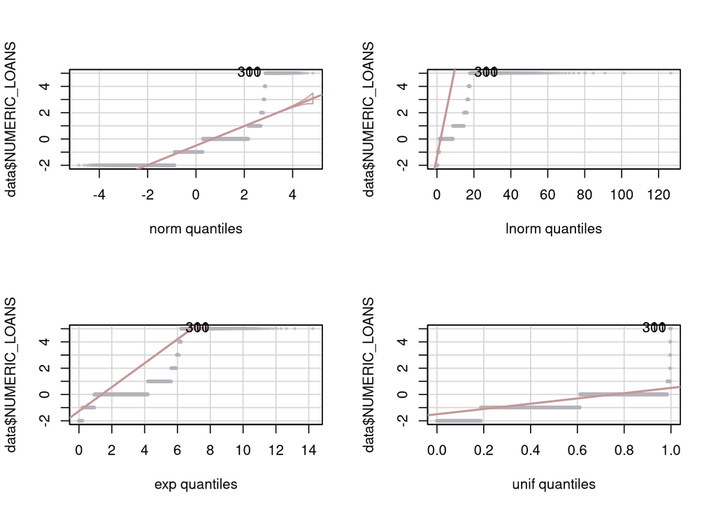

```
## [1] 300 311
```

```r
qqPlot(data$NUMERIC_LOANS, "unif",  pch="*", col=LIGHT_PURPLE, col.lines=DARK_PINK)
```

As we can see, the distributions of the total annual income and the loans are not following any of the tested distributions, such as: normal, log-normal, exponential or uniform.

###### Logistic Regression Model

We want to predict whether the client will belong to the class of debtors who have not repaid the loan correctly (i.e. the client will be considered bad) or to the class of good clients. (We consider a client to be a good client if he has repaid the loan in the current month.) For this we will use logistic regression. Since it is used to predict a class (or category) of people based on one or more predictor variables (x). It is used to model a binary outcome, that is, a variable that can only have two possible values: 0 or 1, yes or no.

But first we will prepare the data. Logistic regression works for data containing continuous and/or categorical predictor variables. So our model will work on variables such as: number of children and family members, annual income, marital status, age, work experience, and type of education.

```r
data_1 <- dplyr::select(merged, ID, CNT_CHILDREN, AMT_INCOME_TOTAL, CNT_FAM_MEMBERS) # create new df with the selected required columns
# Parse string data into numeric and save into new data frame:
data_1$NUMERIC_AGE  <- sapply(merged$DAYS_BIRTH, FUN=parse_age)
data_1$NUMERIC_LOANS  <- sapply(merged$STATUS, FUN=parse_statuses)
data_1$NUMERIC_WORKING_YEARS  <- sapply(merged$DAYS_EMPLOYED, FUN=parse_working_years)
data_1$NUMERIC_EDU    <- sapply(merged$NAME_EDUCATION_TYPE, FUN=parse_education_2)
data_1$NUMERIC_FAMILY <- sapply(merged$NAME_FAMILY_STATUS, FUN=parse_family_status_2)
#We consider a client to be a good client if he has repaid the loan in the current month
data_1$has_loan <- data_1$NUMERIC_LOANS > -1 #Bad cliant - TRUE, good cliant - FALSE
head(data_1)
```

```
##        ID CNT_CHILDREN AMT_INCOME_TOTAL CNT_FAM_MEMBERS NUMERIC_AGE
## 1 5008804            0           427500               2          32
## 2 5008804            0           427500               2          32
## 3 5008804            0           427500               2          32
## 4 5008804            0           427500               2          32
## 5 5008804            0           427500               2          32
## 6 5008804            0           427500               2          32
##   NUMERIC_LOANS NUMERIC_WORKING_YEARS NUMERIC_EDU NUMERIC_FAMILY has_loan
## 1            -1                    12           2              0    FALSE
## 2            -1                    12           2              0    FALSE
## 3            -1                    12           2              0    FALSE
## 4            -1                    12           2              0    FALSE
## 5            -1                    12           2              0    FALSE
## 6            -1                    12           2              0    FALSE
```

```r
# Split the data into training and test set
set.seed(123)
training.samples <- data_1$has_loan %>%
  createDataPartition(p = 0.8, list = FALSE)
train.data  <- data_1[training.samples, ]
test.data <- data_1[-training.samples, ]
```

Logistic regression does not directly return a class of observations. It allows us to estimate the probability (p) of belonging to the class. The probability will range from 0 to 1. The default setting is p = 0.5.

```r
# Fit the model
model <- glm(has_loan ~ CNT_CHILDREN + AMT_INCOME_TOTAL + CNT_FAM_MEMBERS + NUMERIC_AGE + NUMERIC_WORKING_YEARS + NUMERIC_EDU + NUMERIC_FAMILY, data = train.data, family = binomial)
# Summarize the model
summary(model)$coef
```

```
##                            Estimate   Std. Error    z value      Pr(>|z|)
## (Intercept)           -4.509537e-01 1.853608e-02 -24.328423 9.810493e-131
## CNT_CHILDREN           7.678312e-02 9.561836e-03   8.030164  9.734214e-16
## AMT_INCOME_TOTAL       4.181910e-07 2.604667e-08  16.055453  5.235520e-58
## CNT_FAM_MEMBERS       -5.906334e-02 8.445686e-03  -6.993315  2.684651e-12
## NUMERIC_AGE            1.192572e-03 2.485667e-04   4.797797  1.604203e-06
## NUMERIC_WORKING_YEARS -1.331950e-03 3.952604e-04  -3.369805  7.522134e-04
## NUMERIC_EDU           -5.804357e-02 5.054922e-03 -11.482586  1.613807e-30
## NUMERIC_FAMILY         2.824317e-02 4.515656e-03   6.254501  3.987901e-10
```

```r
# Make predictions
probabilities <- model %>% predict(test.data, type = "response")
predicted.classes <- ifelse(probabilities > 0.5, "TRUE", "FALSE")
# Model accuracy
mean(predicted.classes == test.data$has_loan)
```

```
## [1] 0.6113076
```